# Modeling and Optimization

Optimization under Uncertainty

Sebastian Souyris

MGMT 6460 Fall 2026

## Roadmap

1. **Part I. Three Approaches towards Uncertainty**
   - Uncertain Data in LP: Three Approaches
   - Robust Optimization
   - Chance Constraints
   - Two-Stage Recourse
   - Comparing Robust, Chance and Recourse Plans
2. **Part II. The Value of Information**
   - Recap: Two-Stage Recourse on Wyndor
   - The Farmer’s Problem: Mean-Yield and Recourse Plans
   - The Newsvendor Model: The Critical Fractile
   - Scenarios from Data: Sample Average Approximation
   - Recourse Models in Excel and Python
   - AI Check: Verifying a Recourse Model
   - Practice: Recourse, Robust and Chance Models
3. Conclusions
4. Appendix: References and Articles

# Uncertain Data in LP: Three Approaches

## Model Recap from Lecture 01: Wyndor Glass Co.

**Wyndor LP model**

$$\begin{aligned}
\max~ Z = 3x_1 &+ 5x_2 &\\
\text{s.t.} \quad
x_1 \phantom{{}+2x_2} &\le 4 &\text{(Plant 1)} \\
2x_2 &\le 12 &\text{(Plant 2)}\\
3x_1 + 2x_2 &\le 18 &\text{(Plant 3)}\\
x_1, x_2 &\ge 0 &
\end{aligned}$$

|  | Doors | Windows | Hours |
| --- | --- | --- | --- |
| Plant 1 | 1 | 0 | 4 |
| Plant 2 | 0 | 2 | 12 |
| Plant 3 | 3 | 2 | 18 |
| Profit | $3,000 | $5,000 |  |

Hours per batch and per week; ${x_1}$, ${x_2}$ batches per week

**Optimal plan.** ${(2, 6)}$, ${Z = 36}$: $36,000 a week. Plants 2 and 3 bind; Plant 1 has 2 idle hours.

## Wyndor’s Numbers are Point Estimates

Lecture 01’s plan: ${(x_1, x_2) = (2, 6)}$, $36,000 a week. It uses every hour of Plants 2 and 3.

- **Hours are forecasts.** Maintenance and absenteeism move them. Say Plant 2 has ${12 \pm 0.5}$ hours and Plant 3 has ${18 \pm 1}$ (one standard deviation)
- **The window market is a rumor.** A competitor may launch a rival window, and Wyndor would have to redesign Product 2 (Windows)

**The optimal plan is fragile.** With normally distributed hours, Plant 2 and Plant 3 each fall short of the plan half the time. ${(2, 6)}$ is feasible in about **one week in four**: ${0.5 \times 0.5 = 0.25}$.

## Sensitivity Analysis of Lecture 04

Lecture 04’s sensitivity report

| Wyndor data | Estimate | Range keeping the basis optimal |
| --- | --- | --- |
| Plant 2 hours | 12 | ${[6, 18]}$, shadow price 1.5 |
| Plant 3 hours | 18 | ${[12, 24]}$, shadow price 1 |
| Door profit | 3 | ${[0, 7.5]}$ |
| Window profit | 5 | ${[2, \infty)}$ |

- Allowable ranges say **when** the optimal basis changes, one parameter at a time
- They do not say which plan to choose when a number is unknown, or when several numbers move at once

## Three Approaches to Address Uncertainty

| Attitude | The model asks for | It needs | Section |
| --- | --- | --- | --- |
| Plan for the worst case | Feasible for **every** value in a range | A range per parameter | Robust optimization |
| Accept a small risk | Feasible with probability ${\ge \alpha}$ | A distribution per parameter | Chance constraints |
| Decide now, adjust later | Best **expected** profit, with later decisions per scenario | Scenarios and probabilities | Two-stage recourse |

## Hard and Soft Constraints

**Hard and soft constraints**

- A hard constraint must hold: a contract, a safety limit.
- A soft constraint can be violated slightly at a cost: overtime, a late order.
- Robust optimization suits hard constraints; chance constraints and recourse suit soft ones.

# Robust Optimization

## Interval Uncertainty

**Robust optimization**

Each uncertain parameter lies in a range (or box) of uncertainty ${[\ell, u]}$ and can take any value in it, independently of the others. Find the best plan that stays feasible for **every** combination.

- Suits hard constraints, and parameters with known bounds
- With ${x \ge 0}$, the worst value of each parameter is one of its two endpoints. Which one depends only on where the parameter sits

## The Conservative Counterpart

The conservative counterpart replaces every parameter by its worst value (Soyster, 1973)

| Where the parameter sits | Worst value | Why |
| --- | --- | --- |
| ${a_{ij}}$ in a ${\le}$ row | largest, ${u}$ | uses the most capacity |
| ${b_i}$ in a ${\le}$ row | smallest, ${\ell}$ | leaves the least capacity |
| ${a_{ij}}$, ${b_i}$ in a ${\ge}$ row | smallest ${a}$, largest ${b}$ | hardest to reach |
| ${c_j}$ in a max objective | smallest, ${\ell}$ | guarantees the profit |

**Equality constraints**

An equation cannot hold for every value in a range. The method needs every constraint in ${\le}$ or ${\ge}$ form.

## Wyndor’s Ranges

| Parameter | Meaning | Estimate | Range of uncertainty | Conservative value |
| --- | --- | --- | --- | --- |
| ${c_1}$ | Door profit ($000) | 3 | ${[2.5, 3.5]}$ | 2.5 |
| ${c_2}$ | Window profit ($000) | 5 | ${[4.5, 5.5]}$ | 4.5 |
| ${a_{11}}$ | Plant 1 hours, doors | 1 | ${[0.8, 1.2]}$ | 1.2 |
| ${a_{22}}$ | Plant 2 hours, windows | 2 | ${[1.8, 2.2]}$ | 2.2 |
| ${a_{31}}$ | Plant 3 hours, doors | 3 | ${[2.5, 3.5]}$ | 3.5 |
| ${a_{32}}$ | Plant 3 hours, windows | 2 | ${[1.5, 2.5]}$ | 2.5 |
| ${b_1}$ | Plant 1 hours available | 4 | ${[3.6, 4.4]}$ | 3.6 |
| ${b_2}$ | Plant 2 hours available | 12 | ${[11, 13]}$ | 11 |
| ${b_3}$ | Plant 3 hours available | 18 | ${[16, 20]}$ | 16 |

## The Conservative Model

**At the estimates**

$$\begin{aligned}
\max~ Z = 3x_1 &+ 5x_2 \\
\text{s.t.} \quad x_1 \phantom{{}+2x_2} &\le 4 \\
2x_2 &\le 12 \\
3x_1 + 2x_2 &\le 18 \\
x_1, x_2 &\ge 0
\end{aligned}$$

${(2, 6)}$, ${Z = 36}$

**Conservative counterpart**

$$\begin{aligned}
\max~ Z = 2.5x_1 &+ 4.5x_2 \\
\text{s.t.} \quad 1.2x_1 \phantom{{}+2.5x_2} &\le 3.6 \\
2.2x_2 &\le 11 \\
3.5x_1 + 2.5x_2 &\le 16 \\
x_1, x_2 &\ge 0
\end{aligned}$$

${(1, 5)}$, ${Z = 25}$

**By hand.** ${x_1 \le 3}$ and ${x_2 \le 5}$. At ${x_2 = 5}$, Plant 3 leaves ${3.5x_1 \le 3.5}$, so ${x_1 = 1}$: ${\;Z = 2.5 + 22.5 = 25}$.

## The Shrunken Region

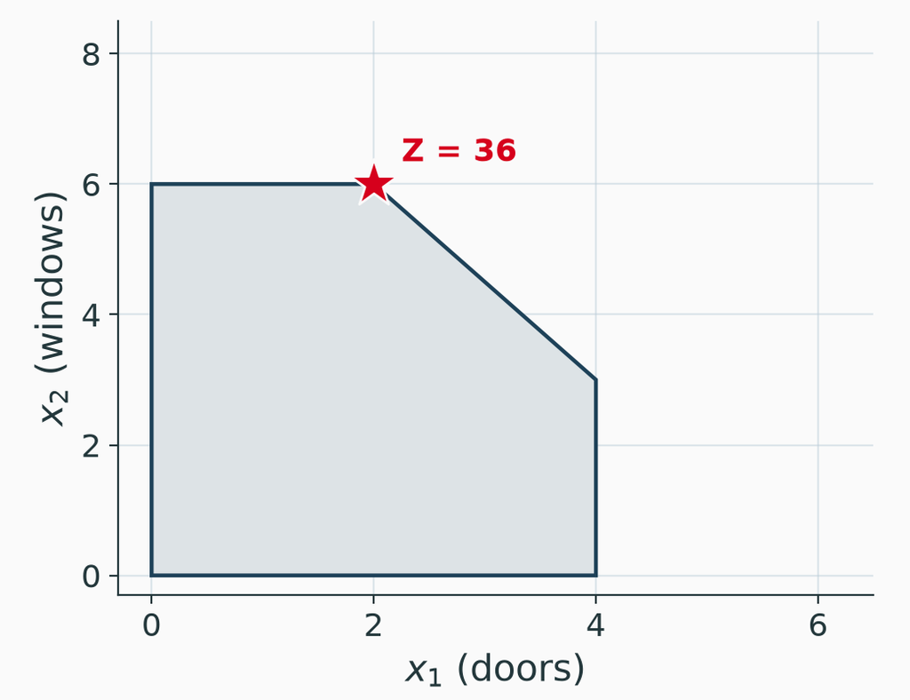

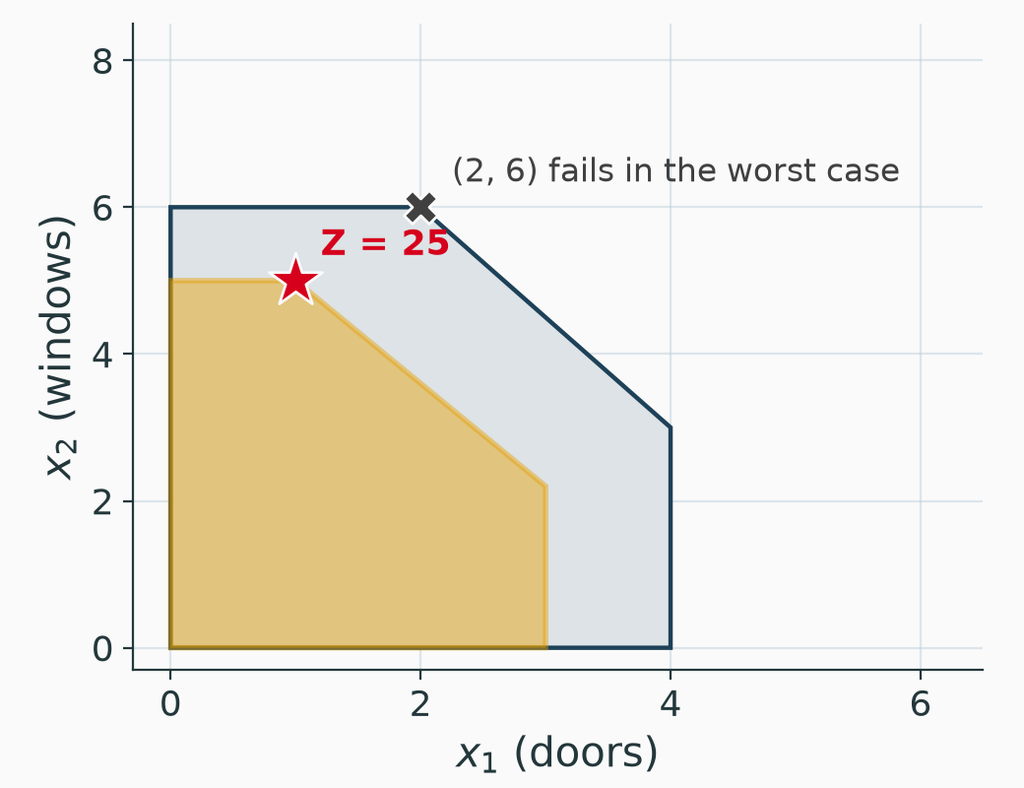

At the estimates, ${(2, 6)}$ earns 36.

At the conservative values, ${(2, 6)}$ needs 13.2 Plant 2 hours and 22 Plant 3 hours against 11 and 16. The region shrinks to the orange one.

**A guarantee**

${(1, 5)}$ is feasible for every value in the ranges and earns at least $25,000 a week.

## What Robustness Costs

| Plan ($000 per week) | Profit at the estimates | Guaranteed profit | Feasible in the worst case |
| --- | --- | --- | --- |
| ${(2, 6)}$, estimates | 36 | none | No |
| ${(1, 5)}$, conservative | 28 | 25 | Yes |

- Feasibility costs ${36 - 28 = 8}$: the smaller region
- Pessimistic profits cost ${28 - 25 = 3}$ more

**The price of robustness**

It guards against all nine parameters at their worst in the same week: a rare week, and the protection can cost more than it is worth.

## Soyster: Every Coefficient at Its Worst

Let ${J_i}$ be the set of columns ${j}$ whose coefficient in row ${i}$ is uncertain (Plant 3: ${J_3 = \{1, 2\}}$). Bertsimas and Sim (2004) model each as ${\tilde a_{ij} = \bar a_{ij} + \eta_{ij}\,\hat a_{ij}}$, ${j \in J_i}$: estimate ${\bar a_{ij}}$, largest deviation ${\hat a_{ij}}$, unknown ${\eta_{ij} \in [-1, 1]}$.

- With ${x \ge 0}$ the worst case is ${\eta_{ij} = 1}$ for **every** uncertain coefficient: ${\;\sum_j \bar a_{ij} x_j + \sum_{j \in J_i} \hat a_{ij} x_j \le b_i}$ (Soyster, 1973)
- Plant 3, both ${\pm 0.5}$: ${\;3x_1 + 2x_2 + 0.5x_1 + 0.5x_2 \le 18}$; at ${(2, 6)}$ the left side is 22

**The objection**

All coefficients at their worst **in the same week**. With 100 of them in a row, that week never comes.

## A Budget of ${\Gamma}$ Deviations

Let nature move **at most ${\Gamma_i}$** coefficients of row ${i}$ to their worst values; a fractional ${\Gamma_i}$ moves one more part of the way.

$$\sum_j \bar a_{ij} x_j + \beta_i(x, \Gamma_i) \le b_i, \qquad
\beta_i(x, \Gamma_i) = \max_{S \subseteq J_i,\ |S| \le \Gamma_i} \; \sum_{j \in S} \hat a_{ij}\, x_j$$

| ${\Gamma}$ | ${\beta}$ at ${(2, 6)}$ | Plant 3 row |
| --- | --- | --- |
| 0 | 0 | 18 fits |
| 0.5 | 1.5 | 19.5 fails |
| 1 | 3 | 21 fails |
| 2 | 3 + 1 = 4 | 22 fails |

- Deviations at ${(2, 6)}$: ${\;0.5 \cdot 2 = 1}$ and ${0.5 \cdot 6 = 3}$
- Nature spends its budget on the **largest** deviation first
- ${\Gamma = 0}$: the nominal row; ${\Gamma = |J_i|}$: Soyster

## The Protection Is an LP

For a fixed plan ${x}$, the worst case is a small LP (Proposition 1). Let ${u_j \in [0, 1]}$ be the share of its range that coefficient ${j}$ moves:

$$\begin{aligned}
\beta_i(x, \Gamma_i) \;=\; \max_{u} \;& \sum_{j \in J_i} \hat a_{ij} x_j\, u_j \\
\text{s.t.} \;& \sum_{j \in J_i} u_j \le \Gamma_i \\
& 0 \le u_j \le 1, \quad j \in J_i
\end{aligned}$$

- Solve it greedily: ${u_j = 1}$ on the largest deviations until the budget runs out, a fraction on the next one
- At ${(2, 6)}$ with ${\Gamma = 1.5}$: ${\;u_2 = 1}$, ${u_1 = 0.5}$, so ${\beta = 3 + 0.5 = 3.5}$

**Still not an LP in x**

A ${\max}$ inside a constraint, with products ${x_j u_j}$: not an LP in ${x}$.

## Duality Removes the Max (Theorem 1)

The dual of the protection LP (lecture 04) has the same optimal value:

$$\beta_i(x, \Gamma_i) \;=\; \min_{z_i,\, p_{ij} \ge 0} \; \Gamma_i z_i + \sum_{j \in J_i} p_{ij}
\quad \text{s.t.} \quad z_i + p_{ij} \ge \hat a_{ij} x_j$$

A ${\min}$ on the left of ${\le b_i}$ holds if **some** ${z_i, p_{ij}}$ fit, so the robust model is one LP:

$$\begin{alignat*}{3}
\max~ & \rlap{c^\top x} \\[4pt]
\text{s.t.}~ & \textstyle\sum_j \bar a_{ij} x_j + \Gamma_i z_i + \sum_{j \in J_i} p_{ij} & \quad & {}\le b_i && \qquad \text{every row } i \\
& z_i + p_{ij} & \quad & {}\ge \hat a_{ij} x_j && \qquad \text{every row } i,\ j \in J_i \\
& x, z, p & \quad & {}\ge 0
\end{alignat*}$$

- Plant 3, ${\Gamma = 1}$: ${(1, 6)}$, ${Z = 33}$; ${\;z = 0.5}$, ${p = (0, 2.5)}$: ${\;15 + 0.5 + 2.5 = 18}$

## How Large Should ${\Gamma}$ Be?

For independent, symmetric deviations, ${P(\text{row } i \text{ fails}) \le e^{-\Gamma_i^2 / (2|J_i|)}}$ for **any** plan.

| ${\lvert J_i \rvert}$ | ${\Gamma_i}$ for ${\le 1\%}$ | Share |
| --- | --- | --- |
| 10 | 8.2 | 82% |
| 100 | 24.3 | 24% |
| 200 | 33.9 | 17% |
| 2,000 | 105 | 5% |

- Table 1 of the paper, Theorem 3 bound
- Knapsack, 200 items, weights ${\pm 10\%}$: Soyster costs 5.5%; a 0.57% violation bound costs 1.54%

**The price of robustness**

For a fixed risk, ${\Gamma_i}$ grows like ${\sqrt{|J_i|}}$: rows with many uncertain coefficients get protection cheaply.

## Interactive: The Budget of Uncertainty

[interactive chart not shown]

# Chance Constraints

## When a Range Has No End

- Robust optimization needs a smallest and a largest value
- Hours that are **normally distributed** have neither: the worst case is ${-\infty}$
- Accept a small probability of a shortfall instead

**Chance constraint (Charnes and Cooper, 1959)**

For a confidence level ${\alpha}$, such as 0.95, require
$$P\Big(\sum_j a_{ij} x_j \le b_i\Big) \;\ge\; \alpha .$$

## The Deterministic Equivalent

Let ${b_i \sim \N(\mu_i, \sigma_i^2)}$ and ${L = \sum_j a_{ij} x_j}$:

$$\begin{aligned}
P(b_i \ge L) \ge \alpha
&\iff \frac{L - \mu_i}{\sigma_i} \le -z_\alpha \\
&\iff \sum_j a_{ij} x_j \;\le\; \mu_i - z_\alpha \sigma_i
\end{aligned}$$

- A linear constraint with a smaller right-hand side
- For a ${\ge}$ row: ${\;\sum_j a_{ij} x_j \ge \mu_i + z_\alpha \sigma_i}$

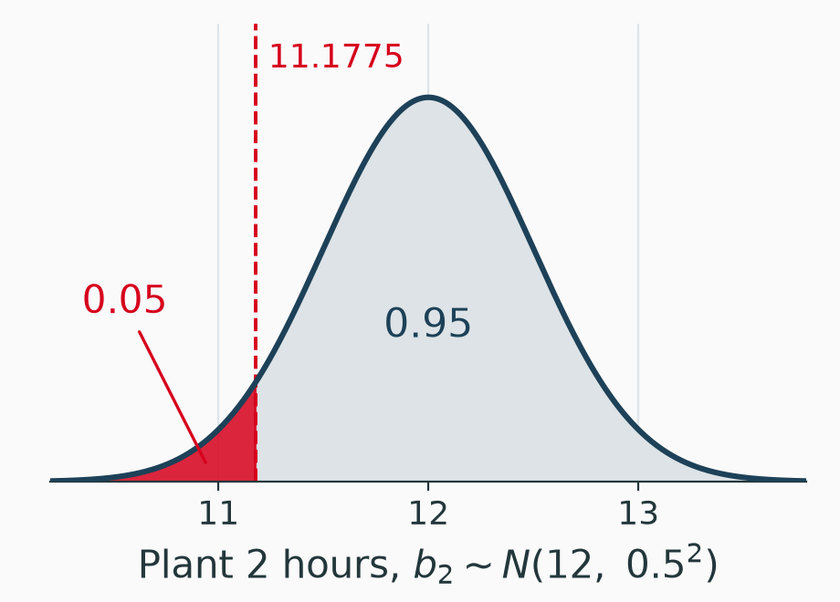

**Standard normal table**

${z_{0.90} = 1.282, \quad z_{0.95} = 1.645, \quad z_{0.975} = 1.960, \quad z_{0.99} = 2.326}$

## Wyndor with Random Hours

Right-hand sides at ${\alpha = 0.95}$

| Plant | ${\mu_i}$ | ${\sigma_i}$ | ${\mu_i - 1.645\,\sigma_i}$ |
| --- | --- | --- | --- |
| 1 | 4 | 0.2 | 3.671 |
| 2 | 12 | 0.5 | 11.1775 |
| 3 | 18 | 1 | 16.355 |

$$\begin{aligned}
\max~ Z = 3x_1 &+ 5x_2 \\
\text{s.t.} \quad x_1 \phantom{{}+2x_2} &\le 3.671 \\
2x_2 &\le 11.1775 \\
3x_1 + 2x_2 &\le 16.355
\end{aligned}$$

- Plants 2 and 3 bind, as before
- ${x_2 = 5.58875}$, ${\;x_1 = (16.355 - 11.1775)/3 = 1.72583}$
- ${Z = 33.121}$: $33,121 a week

## Each Row 0.95, All Rows Less

- Plant 1: the plan uses 1.73 of 4 expected hours, so it holds almost surely
- Plants 2 and 3 bind: each holds with probability 0.95
- Independent hours: both hold with probability ${0.95^2 = 0.9025}$

| Plan | Weeks feasible (2 million simulated) |
| --- | --- |
| ${(2, 6)}$, estimates | 0.2500 |
| ${(1.726, 5.589)}$, chance constraints | 0.9024 |

**Joint chance constraint**

All rows with probability 0.95: each binding row needs ${\sqrt{0.95} = 0.9747}$, so ${z = 1.955}$ and ${Z = 32.580}$.

# Two-Stage Recourse

## Wyndor’s Rumor

A competitor may launch a window that competes with Product 2. If it does, Wyndor redesigns the window: Plant 3 needs 6 hours per batch and the profit falls to $1,000.

Doors are unaffected

| Scenario | Probability | Plant 3 hours per window batch | Profit per window batch |
| --- | --- | --- | --- |
| 1: no competitor | 1/4 | 2 | 5 |
| 2: competitor | 3/4 | 6 | 1 |

- Doors must start **now**; window production can wait until the rumor resolves

## Each Scenario Alone

**Scenario 1, no competitor**

$$\begin{aligned}
\max~ Z = 3x_1 &+ 5x_2 \\
x_1 &\le 4 \\
2x_2 &\le 12 \\
3x_1 + 2x_2 &\le 18
\end{aligned}$$
${(2, 6)}$, ${Z = 36}$

**Scenario 2, competitor**

$$\begin{aligned}
\max~ Z = 3x_1 &+ 1x_2 \\
x_1 &\le 4 \\
2x_2 &\le 12 \\
3x_1 + 6x_2 &\le 18
\end{aligned}$$
${(4, 1)}$, ${Z = 13}$

**Two answers for one decision**

Doors start before the rumor resolves, so ${x_1}$ must be one number. The scenarios disagree: 2 batches or 4?

## Here-and-Now and Wait-and-See

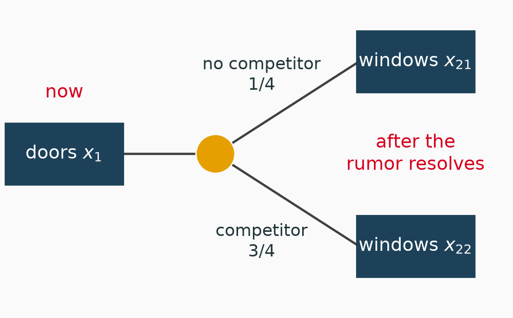

**Two-stage stochastic program**

- First stage, here-and-now: ${x_1}$, one value, before the scenario is known
- Second stage, the recourse: ${x_{2s}}$, one value **per scenario**, after it is known
- Maximize the first-stage profit plus the **expected** second-stage profit (Dantzig, 1955)

## The Extensive Form

$$\begin{alignat*}{3}
\max~ & \rlap{Z = 3x_1 + \tfrac14\,(5x_{21}) + \tfrac34\,(1x_{22})} \\[4pt]
\text{s.t.}~ & x_1 & \quad & {}\le 4 \\
& 2x_{21} & \quad & {}\le 12 && \qquad \text{scenario 1} \\
& 3x_1 + 2x_{21} & \quad & {}\le 18 && \qquad \text{scenario 1} \\
& 2x_{22} & \quad & {}\le 12 && \qquad \text{scenario 2} \\
& 3x_1 + 6x_{22} & \quad & {}\le 18 && \qquad \text{scenario 2} \\
& x_1,\; x_{21},\; x_{22} & \quad & {}\ge 0
\end{alignat*}$$

- One LP: a copy of each scenario’s constraints, all sharing ${x_1}$
- Each scenario’s profit is weighted by its probability

**Solution**

${x_1 = 4}$; ${\;x_{21} = 3}$ if no competitor; ${\;x_{22} = 1}$ if competitor. Expected profit **16.5**: $16,500 a week.

## Solving It by Hand

Fix ${x_1}$; each scenario fills its tightest plant:

$$x_{21} = \min\big(6, \tfrac{18 - 3x_1}{2}\big), \qquad
x_{22} = \min\big(6, \tfrac{18 - 3x_1}{6}\big)$$

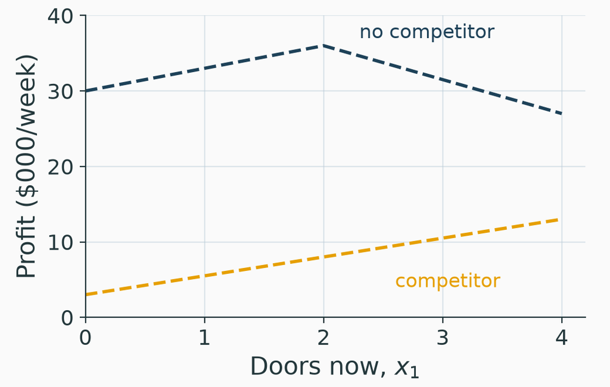

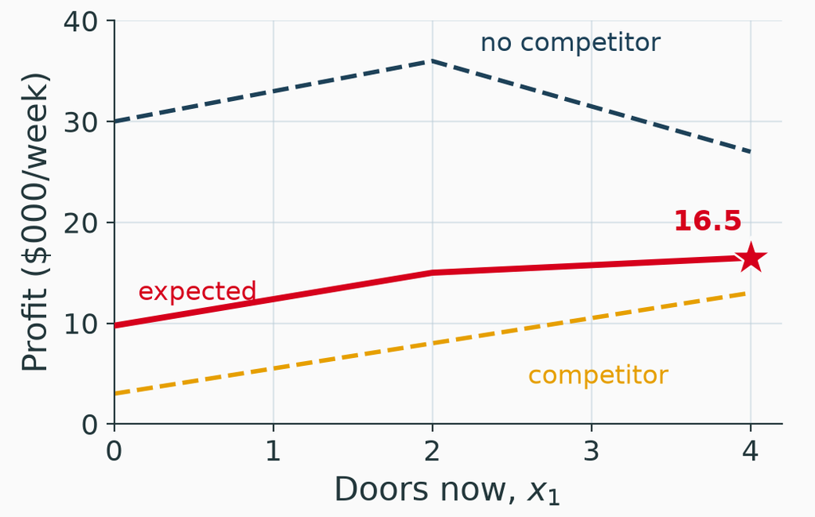

| ${x_1}$ | No comp. | Comp. | Expected |
| --- | --- | --- | --- |
| 0 | 30 | 3 | 9.75 |
| 2 | 36 | 8 | 15 |
| 4 | 27 | 13 | 16.5 |

On ${[2, 4]}$ the expected profit is ${13.5 + 0.75x_1}$: it rises, so ${x_1 = 4}$.

## Plans Compared

Profit in $000 per week; windows chosen after the rumor resolves in every row

| Plan | No competitor (1/4) | Competitor (3/4) | Expected |
| --- | --- | --- | --- |
| ${x_1 = 2}$, best if no competitor | 36 | 8 | 15 |
| ${x_1 = 4}$, the recourse solution | 27 | 13 | 16.5 |
| Perfect information: the right ${x_1}$ for each | 36 | 13 | 18.75 |

- A perfect forecast of the competitor’s move is worth ${18.75 - 16.5 = 2.25}$: $2,250 a week. Part II names this the expected value of perfect information
- Planning for the **average** scenario (window profit 2, Plant 3 needs 5 hours) also picks ${x_1 = 4}$ here. Part II shows a case where the average misleads

# Comparing Robust, Chance and Recourse Plans

## The Three Answers on Wyndor

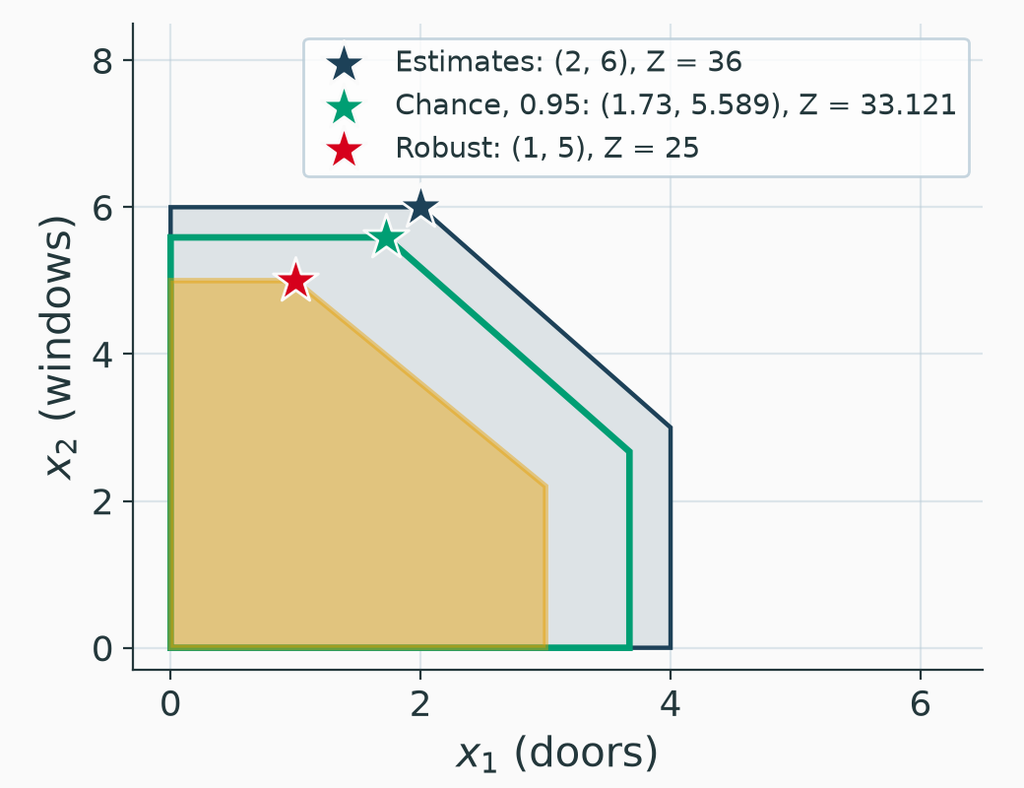

| Attitude | Promise |
| --- | --- |
| Robust | Feasible for every value in the ranges |
| Chance | Each row holds in 95% of weeks |
| Recourse | Best expected profit, windows adjusted per scenario |

- Recourse answers a different question (the rumor), so it is not on the plot

## The Workbook

**Download Wyndor_Uncertainty.xlsx and open it**

Three sheets, each opening at its optimum with Solver set up: objective cell orange, changing cells yellow, data blue.

| Sheet | Model | Opens at |
| --- | --- | --- |
| Robust | Conservative values, estimates beside them | ${(1, 5)}$, ${Z = 25}$ |
| Chance | Hours ${\mu_i - z\,\sigma_i}$ as formulas | ${(1.726, 5.589)}$, ${33.121}$ |
| Recourse | Extensive form, a window column per scenario | ${(4;\ 3, 1)}$, ${16.5}$ |

## Try It in the Workbook

**Download Wyndor_Uncertainty.xlsx and open it**

1. **Chance.** Change ${z}$ to 2.326 (${\alpha = 0.99}$) and re-solve. How much profit does the extra protection cost?
2. **Recourse.** Lower the competitor’s probability from 0.75 to 0.6 and re-solve. What happens to ${x_1}$?
3. **Robust.** Put Plant 3’s coefficients back to 3 and 2. Which constraint now binds?

## Practice: A Conservative Counterpart

**Practice Problem**

$$\begin{alignat*}{2}
\max~ & \rlap{Z = 5x_1 + c_2x_2 + c_3x_3} \\[4pt]
\text{s.t.}~ & a_{11}x_1 - 3x_2 + 2x_3 & \quad & {}\le b_1 \\
& 3x_1 + a_{22}x_2 + x_3 & \quad & {}\ge b_2 \\
& 2x_1 - 4x_2 + a_{33}x_3 & \quad & {}\le 20 \\
& x_1, x_2, x_3 & \quad & {}\ge 0
\end{alignat*}$$

**(a)** Solve at the estimates.  
**(b)** Write and solve the conservative counterpart.  
**(c)** By what percentage does ${Z}$ fall?

| Parameter | Estimate | Range |
| --- | --- | --- |
| ${a_{11}}$ | 4 | ${[3.6, 4.4]}$ |
| ${a_{22}}$ | ${-1}$ | ${[-1.4, -0.6]}$ |
| ${a_{33}}$ | 3 | ${[2.5, 3.5]}$ |
| ${b_1}$ | 30 | ${[27, 33]}$ |
| ${b_2}$ | 20 | ${[19, 22]}$ |
| ${c_2}$ | ${-8}$ | ${[-9, -7]}$ |
| ${c_3}$ | 4 | ${[3, 5]}$ |

## Practice: Chance Constraints

**Practice Problem**

$$\begin{aligned}
\max~ Z = 20x_1 + 30x_2 &+ 25x_3 \\
\text{s.t.} \quad 3x_1 + x_2 + x_3 &\le b_1 \\
2x_1 + 4x_2 + 2x_3 &\le b_2 \\
x_1 + 3x_2 + 5x_3 &\le b_3 \\
x_1, x_2, x_3 &\ge 0
\end{aligned}$$

The ${b_i}$ are independent normals with ${(\mu, \sigma) = (90, 3)}$, ${(150, 6)}$ and ${(180, 9)}$.

1. Write the deterministic equivalent of each constraint for ${\alpha = 0.95}$.
2. Solve the model. Compare ${Z}$ with the model at the means.
3. If all three rows bind, with what probability do they hold together?

## Part II: The Value of Information

Plant now, learn the yield, then buy or sell.

# Recap: Two-Stage Recourse on Wyndor

## Model Recap from Part I: Wyndor with Recourse

Doors ${x_1}$ now; windows after the rumor, ${x_{21}}$ or ${x_{22}}$ (1/4, 3/4).

$$\begin{alignat*}{3}
\max~ & \rlap{Z = 3x_1 + \tfrac14\,(5x_{21}) + \tfrac34\,(1x_{22})} \\
\text{s.t.}~ & x_1 & \quad & {}\le 4 \\
& 2x_{21} & \quad & {}\le 12 && \qquad \text{no competitor} \\
& 3x_1 + 2x_{21} & \quad & {}\le 18 && \qquad \text{no competitor} \\
& 2x_{22} & \quad & {}\le 12 && \qquad \text{competitor} \\
& 3x_1 + 6x_{22} & \quad & {}\le 18 && \qquad \text{competitor} \\
& x_1, x_{21}, x_{22} & \quad & {}\ge 0
\end{alignat*}$$

**Recourse solution**

${x_1 = 4}$; ${\;x_{21} = 3}$, ${\;x_{22} = 1}$; expected profit 16.5 ($000/week). With perfect information, 18.75.

# The Farmer’s Problem: Mean-Yield and Recourse Plans

## A Farmer Plants before the Weather

Birge and Louveaux (2011, Sec. 1.1): 500 acres, three crops, one planting decision before the season.

|  | Wheat | Corn | Sugar beets |
| --- | --- | --- | --- |
| Mean yield (tons/acre) | 2.5 | 3 | 20 |
| Planting cost ($/acre) | 150 | 230 | 260 |
| Selling price ($/ton) | 170 | 150 | 36 up to 6,000 tons; 10 above |
| Purchase price ($/ton) | 238 | 210 | not bought |
| Cattle feed need (tons) | 200 | 240 | none |

- After the harvest the farmer **sells** surplus and **buys** shortfalls
- The beet quota makes revenue piecewise linear: $36 a ton, then $10

## The Mean-Yield Plan

$$\begin{alignat*}{2}
\max~ & \rlap{-150x_W - 230x_C - 260x_B} \\
& \rlap{{} + 170w_W - 238y_W} \\
& \rlap{{} + 150w_C - 210y_C} \\
& \rlap{{} + 36u + 10v} \\[4pt]
\text{s.t.}~ & x_W + x_C + x_B & \quad & {}\le 500 \\
& 2.5x_W + y_W - w_W & \quad & {}\ge 200 \\
& 3x_C + y_C - w_C & \quad & {}\ge 240 \\
& u + v & \quad & {}\le 20x_B \\
& u & \quad & {}\le 6000 \\
& x, w, y, u, v & \quad & {}\ge 0
\end{alignat*}$$

- ${x}$: acres; ${w}$, ${y}$: tons sold and bought; ${u}$, ${v}$: beets at $36 and at $10

**Expected value (EV) solution**

120 acres of wheat, 80 of corn, 300 of beets. Profit **$118,600**.

- 300 acres × 20 tons fills the quota exactly: a plan built for one year

## Three Kinds of Year

Yields 20% above the mean, at the mean, or 20% below, each with probability 1/3.

Each row solves the mean-yield LP with that year’s yields

| Year | Yields (tons/acre) | Best plan if known in advance | Profit |
| --- | --- | --- | --- |
| Good | 3, 3.6, 24 | 183.3 wheat, 66.7 corn, 250 beets | 167,667 |
| Average | 2.5, 3, 20 | 120, 80, 300 | 118,600 |
| Bad | 2, 2.4, 16 | 100, 25, 375 | 59,950 |

**Planting cannot wait**

Three years, three plans, one field. Acres are a here-and-now decision, exactly like Wyndor’s doors.

## The Recourse Model

$$\begin{alignat*}{3}
\max~ & \rlap{-150x_W - 230x_C - 260x_B} \\
& \rlap{{} + \sum_{s=1}^{3} \tfrac{1}{3} \big(170w_{Ws} - 238y_{Ws} + 150w_{Cs} - 210y_{Cs} + 36u_s + 10v_s\big)} \\[6pt]
\text{s.t.}~ & x_W + x_C + x_B & \quad & {}\le 500 \\
& t_{Ws}\,x_W + y_{Ws} - w_{Ws} & \quad & {}\ge 200 && \qquad s = 1, 2, 3 \\
& t_{Cs}\,x_C + y_{Cs} - w_{Cs} & \quad & {}\ge 240 && \qquad s = 1, 2, 3 \\
& u_s + v_s & \quad & {}\le t_{Bs}\,x_B && \qquad s = 1, 2, 3 \\
& u_s & \quad & {}\le 6000 && \qquad s = 1, 2, 3 \\
& x, w, y, u, v & \quad & {}\ge 0
\end{alignat*}$$

- ${t_{cs}}$: yield of crop ${c}$ in scenario ${s}$ (tons/acre)
- **First stage:** 3 acreages, no scenario index. **Second stage:** 6 per scenario

## The Recourse Plan

**Recourse solution (RP)**

170 acres of wheat, 80 of corn, 250 of beets. Expected profit **$108,390**.

Second-stage decisions of the recourse plan

| After the harvest | Good year | Average year | Bad year |
| --- | --- | --- | --- |
| Wheat sold (tons) | 310 | 225 | 140 |
| Corn sold or bought (tons) | sell 48 | 0 | buy 48 |
| Beets sold at $36 (tons) | 6,000 | 5,000 | 4,000 |
| Profit ($) | 167,000 | 109,350 | 48,820 |

- 250 acres of beets reach the quota only in a good year: no beet is ever sold at $10. The plan gives up 50 acres of beets to hedge

## The Mean Plan in Every Year

Plant the EV acreage (120, 80, 300), then sell and buy the best way once the weather is known:

Expected result of the EV solution: (148,000 + 118,600 + 55,120)/3 = **107,240**

| Year | Wheat | Corn | Beets | Profit |
| --- | --- | --- | --- | --- |
| Good | sell 160 | sell 48 | 6,000 at $36, **1,200 at $10** | 148,000 |
| Average | sell 100 | 0 | 6,000 at $36 | 118,600 |
| Bad | sell 40 | **buy 48** | 4,800 at $36 | 55,120 |

**The average plan, in no average year**

In a good year the extra beets sell at $10. In a bad year the farmer buys corn at $210. Neither loss shows up at mean yields.

# The Newsvendor Model: The Critical Fractile

## The Smallest Recourse Model

A store orders ${q}$ units **before** demand ${D}$ is known; it sells ${\min(q, D)}$ and salvages the rest.

- Price 48, cost 22, salvage 8 ($ per unit)
- Underage cost ${c_u = 48 - 22 = 26}$: a sale lost
- Overage cost ${c_o = 22 - 8 = 14}$: a unit left over
- One more unit pays if ${\;c_u\,P(D > q) \ge c_o\,P(D \le q)}$

**Critical fractile**

$$P(D \le q^*) = \frac{c_u}{c_u + c_o} = \frac{26}{40} = 0.65$$
With ${D \sim \N(500, 100^2)}$: ${q^* = 500 + 0.385 \times 100 = 538.5}$.

## Where the Critical Fractile Comes From

Raise the order from ${q}$ to ${q + 1}$, with ${F(q) = P(D \le q)}$:

| Demand | Probability | The extra unit |
| --- | --- | --- |
| ${D > q}$ | ${1 - F(q)}$ | sells: gain ${c_u}$ |
| ${D \le q}$ | ${F(q)}$ | is left over: lose ${c_o}$ |

The extra unit adds ${c_u\,(1 - F(q)) - c_o\,F(q)}$ in expectation. This falls as ${q}$ grows; the best order sets it to zero:

$$c_u\,(1 - F(q^*)) = c_o\,F(q^*)
\quad\Longrightarrow\quad
F(q^*) = \frac{c_u}{c_u + c_o}$$

**Why q* sits above the mean**

A lost sale (26) costs more than a leftover (14). With ${c_u = c_o}$, ${q^*}$ is the mean.

## Interactive: The Newsvendor

[interactive chart not shown]

# Scenarios from Data: Sample Average Approximation

## Where Scenarios Come From

| Source | Example | Watch for |
| --- | --- | --- |
| History | The last 30 seasons’ yields | The past may not repeat |
| Forecasting model | A demand model; a weather ensemble | Calibration of the model |
| Simulation | A model of the process, run many times | Its assumptions |

**From prediction to decision**

A forecasting or machine learning model that samples possible futures feeds a stochastic program directly: each sample is a scenario. The model predicts; the optimization decides.

## Sample Average Approximation

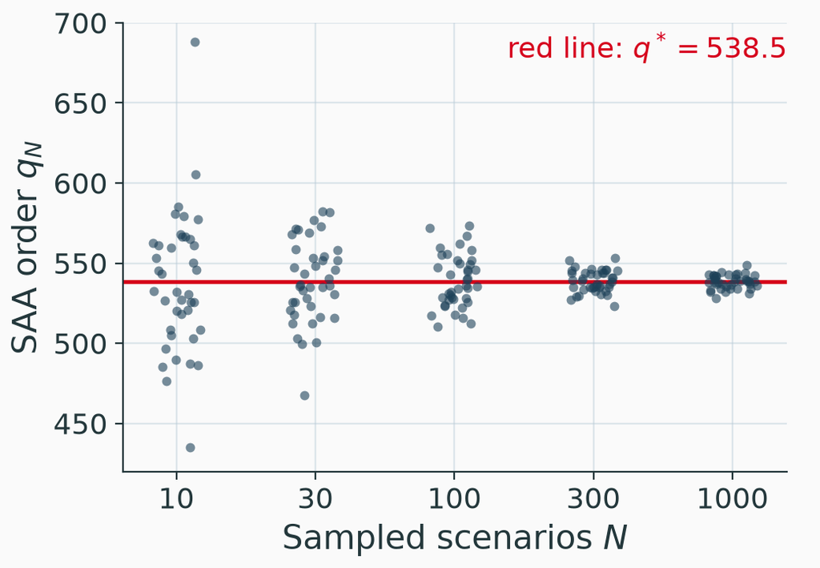

**SAA**

Draw ${N}$ scenarios, give each probability ${1/N}$, and solve the extensive form (Kleywegt et al., 2002).

- Each dot: one sample of ${N}$ demands
- ${q_N \to q^*}$ as ${N}$ grows
- Judge a plan on **fresh** samples

## SAA on the Farmer

Yields drawn independently, each crop uniform within ±20% of its mean; every plan evaluated on 100,000 fresh seasons.

From the notebook farmer_recourse.ipynb (gurobipy)

| Scenarios ${N}$ | Acres of wheat across 5 samples | Profit on fresh seasons |
| --- | --- | --- |
| 10 | 110 to 149 | $109,738 to $110,970 |
| 30 | 128 to 146 | $111,028 to $111,210 |
| 300 | 131 to 138 | $111,169 to $111,210 |
| EV plan | 120 | $110,064 |

- With 10 scenarios the plan depends on the sample, and one of five does worse than the EV plan. From 30 on, every SAA plan beats it

# Recourse Models in Excel and Python

## The Farmer Workbook

**Download Farmer_Recourse.xlsx and open it**

Two sheets with Solver set up. **Mean**: the mean-yield model, at 120, 80, 300 and $118,600. **Recourse**: the extensive form, acres in one row and one row of sales and purchases per scenario, at 170, 80, 250 and $108,390.

1. On **Mean**, type the good-year yields 3, 3.6, 24 and re-solve: the plan you would choose knowing the weather
2. On **Recourse**, type 120, 80, 300 as acres, remove them from the changing cells and re-solve: the mean plan’s expected profit
3. How much more does the recourse plan earn per season?

## The Notebook [farmer_recourse.ipynb](https://colab.research.google.com/drive/1yHds7-RknmXqFOgVQKhoi2YR-oZyVLP1)

- The extensive form as one function of a scenario dictionary
- The mean-yield plan and the recourse plan for the three scenarios
- 100 sampled scenarios, then SAA with 10 to 300 scenarios judged on 100,000 fresh seasons
- Open in Colab, then File, Save a copy in Drive

```python
w = m.addVars(["wheat", "corn"], S, name="sell")   # one per scenario
y = m.addVars(["wheat", "corn"], S, name="buy")
x = m.addVars(crops, name="acres")                 # no scenario index
```

# AI Check: Verifying a Recourse Model

## Your Turn: Ask, Then Verify

**In class**

1. Paste the farmer’s problem, as on these slides, into an AI assistant. Ask for the two-stage stochastic program and gurobipy code that solves it
2. **Before running anything**, read the code: which variables carry a scenario index, and which do not?
3. Run it in Colab (start with `%pip install gurobipy`). Does it return 170, 80, 250 acres and RP = $108,390? If not, find the error

**Course policy**

Cite any AI use with the full exchange: date, tool, prompt, reply.

## One Exchange, Checked

**Claude Haiku 5.5**, 2026-10-22. Key lines of the code it returned:

```python
x    = m.addVars(crops, name="acres")                 # 3 variables
buy  = m.addVars(scen, recourse_crops, name="buy")    # 3 x 2
sell = m.addVars(scen, recourse_crops, name="sell")   # 3 x 2
q    = m.addVars(scen, name="beets_quota")            # 3
r    = m.addVars(scen, name="beets_over")             # 3
```

- It stated 170, 80, 250 and $108,390, and said it had **not run** the code

**Verified**

Acres: no scenario index. Sales and purchases: one per scenario. Run unchanged, it returns 170, 80, 250 and $108,390: correct.

## The Error to Look For

Suppose `sell`, `buy`, `q` and `r` lose their scenario index.

- **Predict.** Which year’s yields limit that plan? What acreage results?
- One sales plan must work in every year: the **bad year** binds
- Every year earns the same revenue: the model is the bad-year LP

**What the solver returns**

100, 25, 375 acres and $59,950: the bad-year plan, buying 180 tons of corn. That is $48,440 below RP, and the model has 9 variables instead of 21.

# Practice: Recourse, Robust and Chance Models

## Practice: A Recourse Model by Hand

**Practice Problem**

A plant makes product A now and product B after B’s demand is known. Each unit of either uses one machine hour; there are 10 hours. A earns $3 per unit and sells at most 9. B earns $8 per unit; its demand is 8 or 2 units, each with probability 1/2.

1. Write the extensive form, with ${x}$ for A and ${y_1, y_2}$ for B.
2. Fix ${x}$, solve each scenario by hand, and find the best ${x}$.
3. Compute EV, EEV and WS, then VSS and EVPI.

## Practice: Robust and Chance Rows

**Practice Problem**

1. Write the conservative counterpart of each row, for ${x \ge 0}$:

$$\begin{aligned}
2x_1 + a_{12}x_2 &\le b_1, & a_{12} &\in [3, 5], & b_1 &\in [18, 22] \\
4x_1 + a_{22}x_2 &\ge b_2, & a_{22} &\in [1.5, 2.5], & b_2 &\in [10, 12]
\end{aligned}$$

2. Demand ${D \sim \N(100, 10^2)}$ must be met with probability 0.90: ${3x_1 + 2x_2 \ge D}$. Use ${z_{0.90} = 1.282}$ and write the deterministic equivalent.
3. Hours ${H \sim \N(40, 4^2)}$ must suffice with probability 0.95: ${x_1 + x_2 \le H}$. Write the deterministic equivalent.

# Conclusions

## Summary of Part I

**Core takeaways**

- Robust: each parameter at its worst value
- ${\Gamma}$ caps how many deviate at once
- Chance: ${\mu_i - z_\alpha \sigma_i}$ for a ${\le}$ row, ${\mu_i + z_\alpha \sigma_i}$ for a ${\ge}$ row
- Recourse: first stage once, second stage per scenario

**Watch out for**

- The worst value depends on ${\le}$ or ${\ge}$
- Separate rows at ${\alpha}$ hold jointly with less
- First-stage variables: **no** scenario index
- Constraints hold in every scenario

## Summary of Part II

**Core takeaways**

- VSS = RP − EEV; EVPI = WS − RP
- ${P(D \le q^*) = c_u / (c_u + c_o)}$
- SAA: judge on fresh samples

**Watch out for**

- EV is not achievable
- Index the second stage by scenario
- Check AI answers with a solver

**Bottom line**

Decide what kind of uncertainty you face before you choose a model: ranges, distributions or scenarios.

## Questions?

Optimization under Uncertainty

MGMT 6460

# Appendix: References and Articles

## Appendix: References

**Textbooks**  
Ben-Tal, A., El Ghaoui, L. and Nemirovski, A. *Robust Optimization*. Princeton University Press, 2009. [doi:10.1515/9781400831050](https://doi.org/10.1515/9781400831050)

Birge, J. R. and Louveaux, F. *Introduction to Stochastic Programming*, 2nd ed. Springer, 2011. Sec. 1.1 (the farmer), ch. 4 (VSS and EVPI). [doi:10.1007/978-1-4614-0237-4](https://doi.org/10.1007/978-1-4614-0237-4)

King, A. J. and Wallace, S. W. *Modeling with Stochastic Programming*. Springer, 2012. [doi:10.1007/978-0-387-87817-1](https://doi.org/10.1007/978-0-387-87817-1)

## Appendix: Articles

Dantzig, G. B. Linear programming under uncertainty. *Management Science* 1(3–4), 197–206, 1955. [doi:10.1287/mnsc.1.3-4.197](https://doi.org/10.1287/mnsc.1.3-4.197)

Charnes, A. and Cooper, W. W. Chance-constrained programming. *Management Science* 6(1), 73–79, 1959. [doi:10.1287/mnsc.6.1.73](https://doi.org/10.1287/mnsc.6.1.73)

Soyster, A. L. Convex programming with set-inclusive constraints and applications to inexact linear programming. *Operations Research* 21(5), 1154–1157, 1973. [doi:10.1287/opre.21.5.1154](https://doi.org/10.1287/opre.21.5.1154)

## Appendix: Articles, Continued

Bertsimas, D. and Sim, M. The price of robustness. *Operations Research* 52(1), 35–53, 2004. [doi:10.1287/opre.1030.0065](https://doi.org/10.1287/opre.1030.0065)

Kleywegt, A. J., Shapiro, A. and Homem-de-Mello, T. The sample average approximation method for stochastic discrete optimization. *SIAM Journal on Optimization* 12(2), 479–502, 2002. [doi:10.1137/S1052623499363220](https://doi.org/10.1137/S1052623499363220)